# Tomey - Assignment 12 - Connectivity

```r
require(tidyverse)
require(terra)
require(sf)
require(gdistance)
require(igraph)
require(fitdistrplus)
require(fdrtool)
require(sf)
require(AICcmodavg)
require(tidyterra)
require(dplyr)
require(raster)
require(landscapemetrics)
```

### Data Import (from lab)

```r
# Read in the landcover raster
land = rast('https://github.com/ValenteJJ/SpatialEcology/raw/main/Week10/panther_landcover.tif')

# Bring in the public lands shapefile
public = st_read('/vsicurl/https://github.com/ValenteJJ/SpatialEcology/raw/main/Week12/panther_publicland.shp')
# Set the crs of the public lands shapefile
st_crs(public) = crs(land)

# And look at it
data.frame(public)
```

|  | OBJECTID | MA_ID | MACODE_BCD | MANAME | MAJORMA | MATYPE | MANAGING_A | MATYPE2 | OWNER | COOWNERS | TOTACRES | LTF_ACRES | COUNTY | PROTSTAT | MANAGER | MGRINST | MGRCITY | MGRPHONE | DESC1 | DESC2 | COMMENTS1 | COMMENTS2 | DIG_COM | MANAME_AB | DESCRIPT | FGDLAQDATE | AUTOID | geometry |
| --- | --- | --- | --- | --- | --- | --- | --- | --- | --- | --- | --- | --- | --- | --- | --- | --- | --- | --- | --- | --- | --- | --- | --- | --- | --- | --- | --- | --- |
| 1 | 9 | 160 | M.USFLHP*193 | FRED C. BABCOCK-CECIL M. WEBB WILDLIFE MANAGEMENT AREA | ZZ | SFWWM | FL FISH AND WILDLIFE CONSERVATION COMMISSION | S | FL FISH AND WILDLIFE CONSERVATION COMMISSION | ZZ | 80335.00 | NA | CHAR, LEEX | 3 | MIKE KEMMERER, BIOLOGICAL SCIENTIST III | FLORIDA FISH & WILDLIFE CONSERVATION COMMISSION | PUNTA GORDA | 941-575-5768 | LARGE AREA OF SOUTH FLORIDA SLASH PINE FLATWOODS CONTAINING ACTIVE RED-COCKADED WOODPECKER COLONIES. ALSO SUPPORTS FLORIDA BLACK BEAR, CRESTED CARACARA, A BIRD ROOKERY AND THE LARGEST KNOWN POPULATION… | S UNIT. | BOUNDARIES IN GIS (1998-07 PAPER QUAD BOUNDARIES ARE OUTDATED). THIS PROPERTY (EXCLUDING THE YUCCA PENS UNIT) IS OWNED BY FL FWCC; WAS PURCHASED WITH PITTMAN/ROBERTSON FUNDS. TOTACRES FROM EXCEL TABLE… | BY PATTI DOERR. BABCOCK-WEBB WMA INCLUDES YUCCA PENS UNIT (M.USFLHP*47). | FNAI MAPPING AND DIGITIZING | BABCOCK-WEBB WMA | FRED C. BABCOCK-CECIL M. WEBB WILDLIFE MANAGEMENT AREA | 2008-12-30 | 52 |  |
| 2 | 553 | 445 | M.USFLHP*130 | BIG CYPRESS NATIONAL PRESERVE | ZZ | FNPNP | US DEPT. OF THE INTERIOR, NATIONAL PARK SERVICE | F | US DEPT. OF INTERIOR, NATIONAL PARK SERVICE | ZZ | 720561.47 | NA | BROW, COLL, DADE, MONR | 1 | JOHN J. DONAHUE, SUPERINTENDENT | ZZ | OCHOPEE | 941-695-2000 | COVERING THE WEST HALF OF THE EVERGLADES, THIS PRESERVE IS A SPECTACULAR MAZE OF SWAMPLANDS AND FLATWOODS, WHICH ARE HOME TO PANTHERS, FLORIDA BLACK BEARS, BIRD ROOKERIES, AND ORCHIDS. THE FEDERAL GOV… | ESERVE BOUNDARY; REST IS OTHER PUBLIC LANDS AND PRIVATE INHOLDINGS. | BOUNDARIES IN GIS (1991-09 BOUNDARIES WERE DRAWN FROM MAP DATED 1987-04, DELIVERED TO FNAI BY MIA VAN HORN 1991-09). TOTACRES FROM 2008-03-17 NPS ACREAGE LIST SENT BY KAROL NEVILLE (EMAIL); INCLUDES 5… | ACRES IN THE ADDITION. AS OF 2008-03-17, THERE ARE 648114.57 ACRES OF FEDERAL LAND, 70706.09 ACRES OF OTHER PUBLIC LAND, AND 1740.81 ACRES OF PRIVATE LAND WITHIN THE PRESERVE BOUNDARY (PER NPS ACREAGE… | COMBINATION OF FNAI MAPPING AND DIGITIZING, AND DIGITAL BOUNDARIES PROVIDED BY COLLIER COUNTY PROPERTY APPRAISER. 02/2008 | BIG CYPRESS NATL PR | BIG CYPRESS NATIONAL PRESERVE | 2008-12-30 | 450 |  |
| 3 | 1029 | 999 | M.USFLHP*663 | OKALOACOOCHEE SLOUGH STATE FOREST | ZZ | SDFSF | FL DEPT. AGRICULTURE AND CONSUMER SERVICES, DIV. OF FORESTRY | S | SOUTH FLORIDA WATER MANAGEMENT DISTRICT | ZZ | 32039.24 | NA | COLL, HEND | 3 | GREG COX, FOREST AREA SUPERVISOR | FL DACS DIVISION OF FORESTRY | FELDA | 863-612-0776; (FAX) 863-612-0780 | A MAJOR HEADWATER FOR FAKAHATCHEE STRAND AND BIG CYPRESS NATIONAL PRESERVE, THIS PROPERTY CONTAINS THOUSANDS OF ACRES OF UNDISTURBED WETLANDS SURROUNDED BY HYDRIC HAMMOCKS DOMINATED BY OAK AND CABBAGE… | ZZ | BOUNDARIES IN GIS. OWNED BY SOUTH FLORIDA WMD AND MANAGED BY FL DACS DOF. FL FWCC IS A SECONDARY MANAGER, SINCE THIS PROPERTY IS ALSO MANAGED AS PART OF OKALOACOOCHEE SLOUGH WMA (SEE M.USFLHP*991). TO… | UDE TRACT OWNED BY FWCC AND UNDER LEAD MANAGEMENT BY THIS AGENCY. | DIGITAL BOUNDARIES PROVIDED BY FDACS DIV. OF FORESTRY. 02/2006 | OKALOACOOCHEE SLOUGH SF | OKALOACOOCHEE SLOUGH STATE FOREST | 2008-12-30 | 1110 |  |
| 4 | 1150 | 1060 | M.USFLHP*432 | KISSIMMEE PRAIRIE PRESERVE STATE PARK | ZZ | SRPSV | FL DEPT. OF ENVIRONMENTAL PROTECTION, DIV. OF RECREATION AND PARKS | S | TRUSTEES OF THE INTERNAL IMPROVEMENT TRUST FUND | SOUTH FLORIDA WATER MANAGEMENT DISTRICT, PRIVATE INDIVIDUAL | 53765.68 | NA | OKEE, OSCE | 1 | CHARLES BROWN | FL DEP DIVISION OF RECREATION AND PARKS | OKEECHOBEE | 863-462-5360; FAX 863-462-5276 | THIS PRESERVE ENCOMPASSES A VAST EXPANSE OF DRY PRAIRIE DIVIDED BY SLOUGHS THAT SUPPORT MESIC AND HYDRIC HAMMOCK. SMALL PATCHES OF SCRUB, XERIC AND MESIC HAMMOCK ARE PRESENT ON HISTORIC LEVEES NEAR TH… | GE FLORIDA GRASSHOPPER SPARROW POPULATION AND PROVIDES HABITAT FOR MANY OTHER BIRD SPECIES. | BOUNDARIES IN GIS. TOTACRES FROM 2002-07 DRP LIST; INCLUDES 51912.65 UPLAND ACRES AND 1853.03 SUBMERGED ACRES). 45621.87 ACRES BELONG TO TRUSTEES (TIITF), 8123.81 ACRES ARE LEASED FROM SOUTH FLORIDA W… | Y-WHITTELL KISSIMMEE PRAIRIE SANCTUARY, FORMERLY OWNED AND MANAGED BY THE NATIONAL AUDUBON SOCIETY, WAS PURCHASED BY THE STATE 2001-11-15 AND WAS ADDED TO THE PRESERVE 2002-06-06 (7311.4 ACRES LEASED … | DIGITAL BOUNDARIES PROVIDED BY FL DEP DIV. OF RECREATION AND PARKS. 04/2006 | KISSIMMEE PRAIRIE PR SP | KISSIMMEE PRAIRIE PRESERVE STATE PARK | 2008-12-30 | 1240 |  |
| 5 | 1345 | 1341 | M.USFLHP*1124 | FLORIDA PANTHER NATIONAL WILDLIFE REFUGE | ZZ | FFWWR | US DEPT. OF THE INTERIOR, FISH AND WILDLIFE SERVICE | F | US FISH & WILDLIFE SERVICE | ZZ | 26605.42 | NA | COLL | 2 | LAYNE HAMILTON, REFUGE MANAGER | U. S. FISH & WILDLIFE SERVICE | NAPLES | 239-353-8442 EXT. 227 | LOCATED APPROXIMATELY 20 MILES EAST OF NAPLES, FLORIDA. THE PRIMARY MISSION OF THIS REFUGE IS TO PROTECT HABITAT FOR THE FEDERALLY ENDANGERED FLORIDA PANTHER AND OTHER WILDLIFE. THE REFUGE IS CLOSED F… | PRESS AND MIXED SWAMP FORESTS, FLATWOODS, HARDWOOD HAMMOCKS, PRAIRIES, MARSHES, AND SLOUGHS. PERMANENT AND SEASONAL WETLANDS COMPRISE APPROXIMATELY 70% OF THE REFUGE ACREAGE. | BOUNDARIES IN GIS (1993-09 BOUNDARIES ON PAPER QUADS ARE OUTDATED, WERE DRAWN FROM STATUS MAP POSTED 1992-12). TOTACRES FROM UPDATED LIST OF ACREAGES FOR FLORIDA NWRS SENT BY CHARLOTTE UNDERWOOD 2007-… | NT OR LEASE (ROAD RIGHT-OF-WAYS, PER LAYNE HAMILTON). | DIGITAL BOUNDARIES PROVIDED BY U. S. FISH AND WILDLIFE SERVICE. 02/2008 | FLORIDA PANTHER NWR | FLORIDA PANTHER NATIONAL WILDLIFE REFUGE | 2008-12-30 | 1284 |  |

```r
publicCentroids = st_centroid(public)
classification = read.table('https://raw.githubusercontent.com/ValenteJJ/SpatialEcology/main/Week12/resistance%20reclass.txt', header=T)
landCost = classify(land, classification[,c(1,3)])
landCost = raster(landCost)
```

# Challenge 1 (5 points)

In the lab, we calculated Euclidean distance, least-cost distance, commute distance (based on circuit theory), and a randomized shortest path distance. Examine the correlation among these 4 metrics of effective distance.

### Euclidean Distance

```r
geoDist = pointDistance(publicCentroids, lonlat=F)
geoDist = as.dist(geoDist)
geoDist
```

```
          1         2         3         4
2 127755.36
3  64612.56  69633.67
4 112427.46 179938.54 117696.82
5  88783.37  40777.14  40788.10 158465.11
```

```r
g1 = c(127755.36, 64612.56, 112427.46, 88783.37)
```

### Least - Cost Distance

```r
landCond = transition(1/landCost, transitionFunction = mean, 8)

landCond = geoCorrection(landCond, type='c', multpl=F)

lcDist = costDistance(landCond, st_coordinates(publicCentroids))
lcDist
```

```
          1         2         3         4
2 250607.85
3 179140.02 131344.61
4 318972.02 470623.60 339278.98
5 191449.65  63048.06  85583.67 424862.66
```

```r
l1 = c(250607.85, 179140.02, 318972.02, 191449.65)
```

### Commute Distance - Circuit Theory

```r
circuitDist = commuteDistance(landCond, st_coordinates(publicCentroids))
circuitDist
```

```
          1         2         3         4
2 1337632.6
3 1221718.7  883745.4
4 1675535.7 1585787.1 1513399.0
5 1271736.3  675481.3  823479.5 1566043.6
```

```r
c1 = c(1337632.6, 1221718.7, 1675535.7, 1271736.3)
```

### Randomized Shortest Path Distance

```r
rspDist1 = rSPDistance(landCond, from=st_coordinates(publicCentroids)[1,], to=st_coordinates(publicCentroids)[2,], theta=0.001)

rspDist2 = rSPDistance(landCond, from=st_coordinates(publicCentroids)[1,], to=st_coordinates(publicCentroids)[3,], theta=0.001)

rspDist3 = rSPDistance(landCond, from=st_coordinates(publicCentroids)[1,], to=st_coordinates(publicCentroids)[4,], theta=0.001)

rspDist4 = rSPDistance(landCond, from=st_coordinates(publicCentroids)[1,], to=st_coordinates(publicCentroids)[5,], theta=0.001)

r1 = rbind(rspDist1, rspDist2, rspDist3, rspDist4)
```

### Correlation Between Distance Metrics

```r
require(PerformanceAnalytics)

Dist = data.frame(
  Euclidean = as.vector(g1),
  LeastCost = as.vector(l1),
  Circuit = as.vector(c1),
  Random = as.vector(r1)
)

Dist
```

| Euclidean | LeastCost | Circuit | Random |
| --- | --- | --- | --- |
| 127755.36 | 250607.9 | 1337633 | 310205.9 |
| 64612.56 | 179140.0 | 1221719 | 219526.1 |
| 112427.46 | 318972.0 | 1675536 | 376189.5 |
| 88783.37 | 191449.6 | 1271736 | 233317.8 |

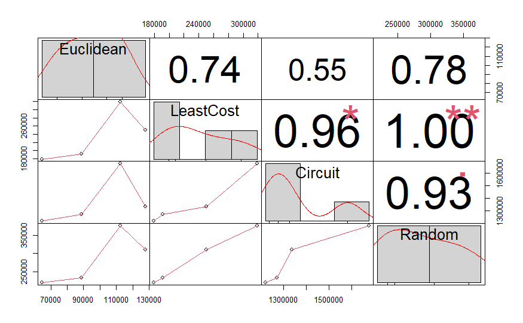

```r
chart.Correlation(Dist, histogram=T)
```

$\color{red}{\text{Excellent. +5}}$

# Challenge 2 (5 points)

In the lab we developed a 10% least-cost corridor between two protected areas. Identify what proportion of this corridor is comprised of each landcover type based on the land raster. To do this, make sure that both the land and leastCostCorridor10 rasters are spatRasters. Then mask land with leastCostCorridor10. The values in the resulting raster will be representative of the landcover values in the corridor. Summarise this information and refer back to the classification dataframe to link the landcover numbers with landcover types.

### Code from Lab

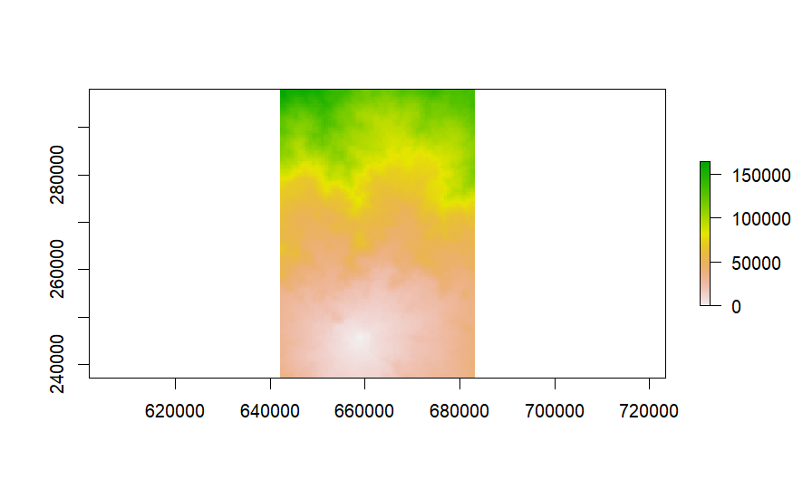

```r
# Choose the extent for cropping
fpwrOssfExtent = extent(642000, 683000, 237000, 298000)

# Crop the landcover layer
landSub = crop(land, fpwrOssfExtent)

# Crop the cost layer and create a transition matrix
landCostSub = crop(landCost, fpwrOssfExtent)
landCondSub = transition(1/landCostSub, transitionFunction=mean, 8)
landCondSub = geoCorrection(landCondSub, type='c', multpl=F)

fpwrCost = accCost(landCondSub, st_coordinates(publicCentroids)[5,])
ossfCost = accCost(landCondSub, st_coordinates(publicCentroids)[3,])

plot(fpwrCost)
```

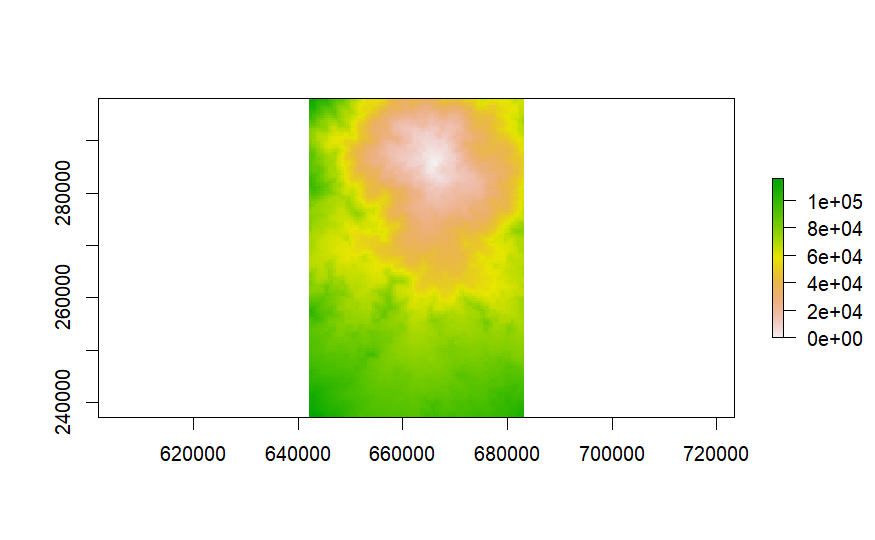

```r
plot(ossfCost)
```

```r
fpwrOssfLcp = shortestPath(landCond, st_coordinates(publicCentroids)[5,], st_coordinates(publicCentroids[3,]), output='SpatialLines')

plot(landCostSub, axes=F)
plot(st_geometry(public), add=T)
```

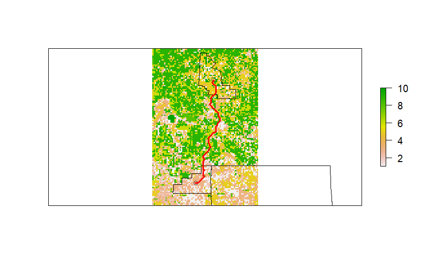

```r
plot(st_geometry(publicCentroids), col='grey30', add=T)
lines(fpwrOssfLcp, col='red', lwd=3)
```

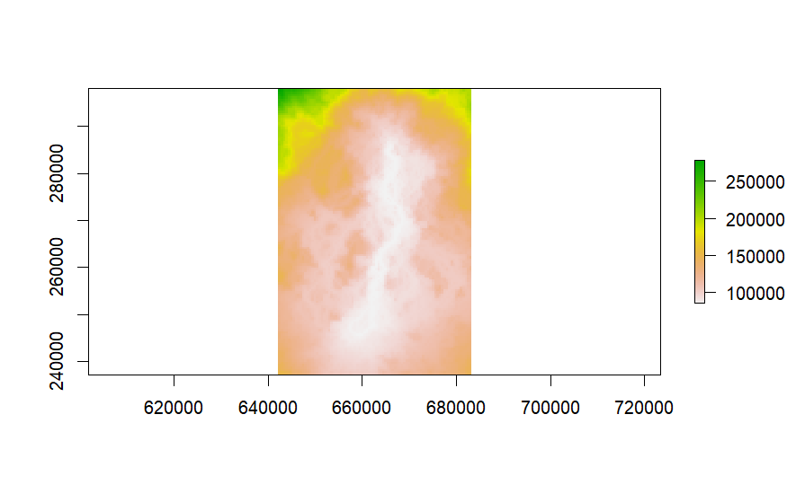

```r
leastCostCorridor = overlay(fpwrCost, ossfCost, fun=function(x, y){return(x+y)})

plot(leastCostCorridor)
```

```r
#Calculate the 10% quantile for the leastCostCorridor raster
quantile10 = quantile(leastCostCorridor, probs=0.1, na.rm=T)
quantile10
```

```
     10%
91850.34
```

```r
#Create a new raster with a value of 1 if it has a summed cost in the lower 10% and a NA otherwise
leastCostCorridor10 = leastCostCorridor
values(leastCostCorridor10) = NA
leastCostCorridor10[leastCostCorridor < quantile10] = 1
```

### Masking Land Cover to Corridor

```r
leastCostCorridor10 = rast(leastCostCorridor10)

plot(leastCostCorridor10, legend=F, axes=F)
points(publicCentroids, col='grey30')
```

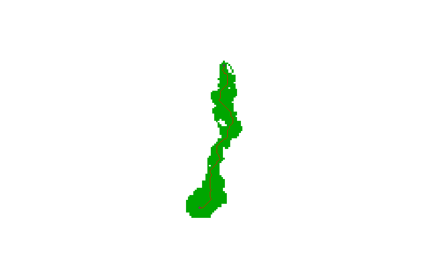

```r
lines(fpwrOssfLcp, col='red')
```

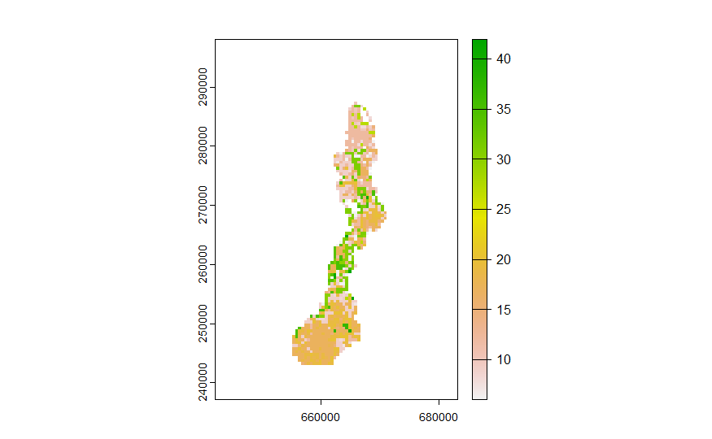

```r
landMask = crop(land, leastCostCorridor10)
landMask = mask(landMask, leastCostCorridor10)
plot(landMask)
```

### Categories for Values

```r
landMask = categories(landMask, value = classification[,c(1,3)])

landProp = lsm_c_pland(landMask, directions = 8)
landProp
```

| layer | level | class | id | metric | value |
| --- | --- | --- | --- | --- | --- |
| 1 | class | 6 | NA | pland | 4.0 |
| 1 | class | 7 | NA | pland | 0.4 |
| 1 | class | 8 | NA | pland | 3.3 |
| 1 | class | 9 | NA | pland | 14.3 |
| 1 | class | 10 | NA | pland | 1.6 |
| 1 | class | 12 | NA | pland | 13.7 |
| 1 | class | 15 | NA | pland | 3.6 |
| 1 | class | 17 | NA | pland | 22.0 |
| 1 | class | 18 | NA | pland | 1.1 |
| 1 | class | 19 | NA | pland | 9.7 |

[output cut: 10 more lines]

```r
classification
```

| Landcover | Description | ChangeTo | Description2 |
| --- | --- | --- | --- |
| 1 | CoastalStrand | 11 | coastalwetland |
| 2 | Sand | 11 | coastalwetland |
| 23 | saltmarsh | 11 | coastalwetland |
| 24 | mangroveswamp | 11 | coastalwetland |
| 25 | scrubmangrove | 11 | coastalwetland |
| 26 | tidalflat | 11 | coastalwetland |
| 34 | citrus | 9 | Cropland |
| 27 | openwater | 10 | OpenWater |
| 33 | sugarcane | 9 | Cropland |
| 35 | rowcrops | 9 | Cropland |

[output cut: 33 more lines]

```r
NA
```

**What are the three most common landcover types within this corridor, and does this make sense given what you know about the resistance to movement within such landcover types?** 1. [17] Cypress Swamp = 22.0 2. [9] Cropland = 14.3 3. [12] Fresh Water Marsh = 13.7

Cypress swamp, cropland, and fresh water marsh as the land cover types with the greatest proportion within the least cost - corridor does make sense. Cypress swamp is a land cover type that we have previously determined to be connected with resource selection and use. Cropland and fresh water marsh may also provide relatively easier routes for panthers to travel through.

$\color{red}{\text{I'm not exactly sure what went wrong here, but hardwood swamp should be in the top 3, not cropland. Either way, good work. +4}}$